# 4일차

```python
import pandas as pd
import seaborn as sns
```

```python
df = pd.read_csv('test1_modify.csv')
df.head()
```

|  | season | holiday | workingday | weather | temp | atemp | humidity | windspeed | casual | registered | count | year | month | day | hour | dayofweek |
| --- | --- | --- | --- | --- | --- | --- | --- | --- | --- | --- | --- | --- | --- | --- | --- | --- |
| 0 | 1 | 0 | 0 | 1 | 9.84 | 14.395 | 81 | 0.0 | 3 | 13 | 16 | 2011 | 1 | 1 | 0 | 5 |
| 1 | 1 | 0 | 0 | 1 | 9.02 | 13.635 | 80 | 0.0 | 8 | 32 | 40 | 2011 | 1 | 1 | 1 | 5 |
| 2 | 1 | 0 | 0 | 1 | 9.02 | 13.635 | 80 | 0.0 | 5 | 27 | 32 | 2011 | 1 | 1 | 2 | 5 |
| 3 | 1 | 0 | 0 | 1 | 9.84 | 14.395 | 75 | 0.0 | 3 | 10 | 13 | 2011 | 1 | 1 | 3 | 5 |
| 4 | 1 | 0 | 0 | 1 | 9.84 | 14.395 | 75 | 0.0 | 0 | 1 | 1 | 2011 | 1 | 1 | 4 | 5 |

```python
df.columns
```

```
Index(['season', 'holiday', 'workingday', 'weather', 'temp', 'atemp',
       'humidity', 'windspeed', 'casual', 'registered', 'count', 'year',
       'month', 'day', 'hour', 'dayofweek'],
      dtype='object')
```

```python
features = ['season', 'holiday', 'workingday', 'weather', 'temp', 'atemp',
            'humidity', 'windspeed', 'year', 'month', 'day', 'hour', 'dayofweek']
label = 'count'

train, test = df[0::2], df[1::2]
train, test = train.reset_index(), test.reset_index()
X_train, y_train = train[features], train[label]
X_test, y_test = test[features], test[label]
```

```python
from sklearn.ensemble import RandomForestRegressor as rf

model = rf()

model.fit(X_train, y_train)

train_score = model.score(X_train, y_train)
test_score = model.score(X_test, y_test)

print(train_score, test_score)
```

```
0.9919101282573053 0.9261003791382316
```

## 결정계수(R-squared, R2)

- coefficient of determination
- 회귀 분석이 얼마나 잘 되었는지 확인하는 평가지표
- 회귀에서는 예측하는 값이나 타깃이 임의의 수치이므로 정확한 숫자를 맞힌다는 것은 거의 불가능 함
- 0~1 사이의 값을 갖고, 1에 가까울수록 예측력이 좋다고 판단(데이터를 잘 설명하는 모델)

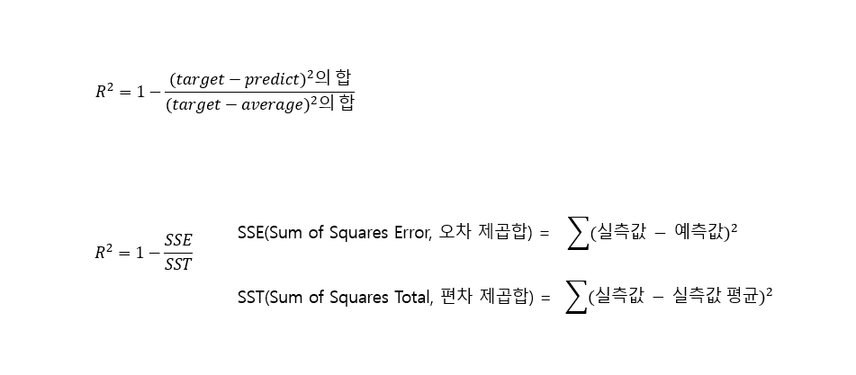

- 샘플의 타깃과 예측한 값의 차이를 제곱하여 더함
- 타깃과 타깃 평균의 차이를 제곱하여 더한 값으로 나눔
- 타깃의 평균 정도를 예측하는 수준이라면(분자와 분모가 비슷하다면) R2는 0에 가까워지고, 예측이 타깃에 가까워지면(분자가 0에 가까워지기 때문에) 1에 가까운 값이 됨

## 과대적합(Over-fitting)과 과소적합(Under-fitting)

- Over-fitting: 샘플에 모델이 과하게 적합되어 있는 상태
- Under-fitting: 샘플에 모델이 너무 부족하게 적합되어 있는 상태

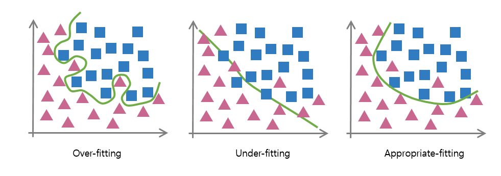

```python
from sklearn.tree import DecisionTreeRegressor as dt

model_dt = dt()
model_dt.fit(X_train, y_train)

train_score = model_dt.score(X_train, y_train)
test_score = model_dt.score(X_test, y_test)
```

```python
test_score
```

```
0.8594069665023909
```

## 다양한 회귀문제 평가지표들

- R(root), M(Mean), S(Squard), L(Log), P(Percentile), A(Absolute), E(Error)
- MAPE: 오차의 비율을 절대값 씌우고 평균
- MAE: 오차를 절대값 씌워서 평균
- MSE: 오차를 제곱해서 평균
- RMSE: 오차를 제곱하여 평균한 것에 제곱근 적용
- RMSLE: 로그오차를 제곱하여 평균한 것에 제곱근 적용

```python
import numpy as np

err1 = np.log(2) - np.log(1)
err2 = np.log(1002) - np.log(1001)

print(err1, err2)
```

```
0.6931471805599453 0.0009985023295895346
```

```python
model.predict(X_train)
```

```
array([ 19.66,  29.96,   3.4 , ..., 559.16, 249.48, 134.74])
```

```python
for_plot = pd.DataFrame()

for_plot['train_predict'] = model.predict(X_train) # 학습용 문제로 문제 풀기
for_plot['train_actual'] = y_train # 학습용 문제의 정답

for_plot['test_predict'] = model.predict(X_test) # 시험용 문제로 문제 풀기
for_plot['test_actual'] = y_test # 시험용 문제의 정답

for_plot.head()
```

|  | train_predict | train_actual | test_predict | test_actual |
| --- | --- | --- | --- | --- |
| 0 | 19.66 | 16 | 20.71 | 40 |
| 1 | 29.96 | 32 | 15.32 | 13 |
| 2 | 3.40 | 1 | 4.80 | 1 |
| 3 | 2.89 | 2 | 31.39 | 3 |
| 4 | 28.56 | 8 | 57.79 | 14 |

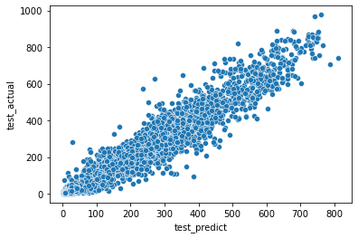

```python
sns.scatterplot(data=for_plot, x='test_predict', y='test_actual')
```

```python
for_plot_dt = pd.DataFrame()

for_plot_dt['train_predict'] = model_dt.predict(X_train) # 학습용 문제로 문제 풀기
for_plot_dt['train_actual'] = y_train # 학습용 문제의 정답

for_plot_dt['test_predict'] = model_dt.predict(X_test) # 시험용 문제로 문제 풀기
for_plot_dt['test_actual'] = y_test # 시험용 문제의 정답

for_plot_dt.head()
```

|  | train_predict | train_actual | test_predict | test_actual |
| --- | --- | --- | --- | --- |
| 0 | 16.0 | 16 | 16.0 | 40 |
| 1 | 32.0 | 32 | 2.0 | 13 |
| 2 | 1.0 | 1 | 2.0 | 1 |
| 3 | 2.0 | 2 | 8.0 | 3 |
| 4 | 8.0 | 8 | 74.0 | 14 |

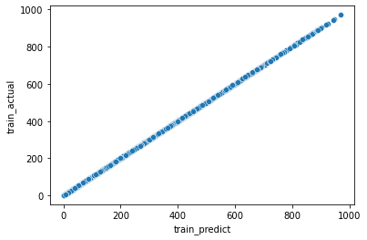

```python
sns.scatterplot(data=for_plot_dt, x='train_predict', y='train_actual')
```

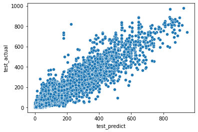

```python
sns.scatterplot(data=for_plot_dt, x='test_predict', y='test_actual')
```

## Feature Selection(변수 선택법)

- 과적합을 방지하고, 일반화를 달성하기 위해 사용하는 방법
- 모든 변수를 다 사용하지 않고 골라서 사용(어떤걸 넣을지, 어떤걸 뺄지)
- 변수를 선택해서 사용하기 때문에 학습속도 증진을 기대할 수 있음(데이터 용량 감소)
- Filter, Wrapper, Embed

#### Filter

- 기초통계량을 기반으로 Feature 간의 관계에서 높은 상관계수(영향력)를 가지는 feature를 사용하는 방법
- ex) 표준편차 0에 가까우면(해당 Column에 저장된 데이터들이 거의 동일) 해당 feature는 삭제
- IOT Sensor data, Smart Factory 쪽 센서류의 경우 종종 발생

```python
df.describe().T.sort_values(by='std')
```

|  | count | mean | std | min | 25% | 50% | 75% | max |
| --- | --- | --- | --- | --- | --- | --- | --- | --- |
| holiday | 10886.0 | 0.028569 | 0.166599 | 0.00 | 0.0000 | 0.000 | 0.0000 | 1.0000 |
| workingday | 10886.0 | 0.680875 | 0.466159 | 0.00 | 0.0000 | 1.000 | 1.0000 | 1.0000 |
| year | 10886.0 | 2011.501929 | 0.500019 | 2011.00 | 2011.0000 | 2012.000 | 2012.0000 | 2012.0000 |
| weather | 10886.0 | 1.418427 | 0.633839 | 1.00 | 1.0000 | 1.000 | 2.0000 | 4.0000 |
| season | 10886.0 | 2.506614 | 1.116174 | 1.00 | 2.0000 | 3.000 | 4.0000 | 4.0000 |
| dayofweek | 10886.0 | 3.013963 | 2.004585 | 0.00 | 1.0000 | 3.000 | 5.0000 | 6.0000 |
| month | 10886.0 | 6.521495 | 3.444373 | 1.00 | 4.0000 | 7.000 | 10.0000 | 12.0000 |
| day | 10886.0 | 9.992559 | 5.476608 | 1.00 | 5.0000 | 10.000 | 15.0000 | 19.0000 |
| hour | 10886.0 | 11.541613 | 6.915838 | 0.00 | 6.0000 | 12.000 | 18.0000 | 23.0000 |
| temp | 10886.0 | 20.230860 | 7.791590 | 0.82 | 13.9400 | 20.500 | 26.2400 | 41.0000 |
| windspeed | 10886.0 | 12.799395 | 8.164537 | 0.00 | 7.0015 | 12.998 | 16.9979 | 56.9969 |
| atemp | 10886.0 | 23.655084 | 8.474601 | 0.76 | 16.6650 | 24.240 | 31.0600 | 45.4550 |
| humidity | 10886.0 | 61.886460 | 19.245033 | 0.00 | 47.0000 | 62.000 | 77.0000 | 100.0000 |
| casual | 10886.0 | 36.021955 | 49.960477 | 0.00 | 4.0000 | 17.000 | 49.0000 | 367.0000 |
| registered | 10886.0 | 155.552177 | 151.039033 | 0.00 | 36.0000 | 118.000 | 222.0000 | 886.0000 |
| count | 10886.0 | 191.574132 | 181.144454 | 1.00 | 42.0000 | 145.000 | 284.0000 | 977.0000 |

#### Wrapper

- feature를 하나씩 넣고, 빼면서 평가지표 점수 확인(시행착오 거친다)
- feature의 조합에 따라서 평가지표의 점수가 달라진다는 것으로부터 출발
- feature 조합별로 평가지표 점수 확인해서 점수가 가장 좋은 조합을 찾아냄
- Wrapper 방법: 전진 선택, 후방 제거, 단계별 선택

```python
features = ['season', 'holiday', 'workingday', 'weather', 'temp', 'atemp',
            'humidity', 'windspeed', 'year', 'month', 'day', 'hour', 'dayofweek']
label = 'count'

train, test = df[0::2], df[1::2]
train, test = train.reset_index(), test.reset_index()

X_train, y_train = train[features], train[label]
X_test, y_test = test[features], test[label]

model = rf()
model.fit(X_train, y_train)
model.score(X_test, y_test)
```

```
0.9250262292234464
```

```python
features = ['season', 'holiday', 'workingday', 'weather', 'temp', 'atemp',
            'humidity', 'windspeed', 'year', 'month', 'day', 'dayofweek']
label = 'count'

train, test = df[0::2], df[1::2]
train, test = train.reset_index(), test.reset_index()

X_train, y_train = train[features], train[label]
X_test, y_test = test[features], test[label]

model = rf()
model.fit(X_train, y_train)
model.score(X_test, y_test)
```

```
0.5236459202555812
```

```python
features = ['season', 'workingday', 'weather', 'temp', 'atemp',
            'humidity', 'windspeed', 'year', 'month', 'day', 'hour', 'dayofweek']
label = 'count'

train, test = df[0::2], df[1::2]
train, test = train.reset_index(), test.reset_index()

X_train, y_train = train[features], train[label]
X_test, y_test = test[features], test[label]

model = rf()
model.fit(X_train, y_train)
model.score(X_test, y_test)
```

```
0.9264198110823287
```

```python
from sklearn.feature_selection import RFE # Recursive Feature Elimination

features = ['season', 'holiday', 'workingday', 'weather', 'temp', 'atemp',
            'humidity', 'windspeed', 'year', 'month', 'day', 'hour', 'dayofweek']
label = 'count'

train, test = df[0::2], df[1::2]
train, test = train.reset_index(), test.reset_index()

X_train, y_train = train[features], train[label]
X_test, y_test = test[features], test[label]

model = rf()
model.fit(X_train, y_train)

selector = RFE(estimator=model)

selector.fit(X_train, y_train)

rfe_df = pd.DataFrame()
rfe_df['rank'] = selector.ranking_
rfe_df['feature'] = features
rfe_df
```

|  | rank | feature |
| --- | --- | --- |
| 0 | 7 | season |
| 1 | 8 | holiday |
| 2 | 2 | workingday |
| 3 | 4 | weather |
| 4 | 1 | temp |
| 5 | 1 | atemp |
| 6 | 3 | humidity |
| 7 | 6 | windspeed |
| 8 | 1 | year |
| 9 | 1 | month |
| 10 | 5 | day |
| 11 | 1 | hour |
| 12 | 1 | dayofweek |

```python
rfe_df.sort_values(by='rank')

# 랭킹이 높은 것들은 학습 대상에서 제외했을 때 성능 하락이 크다고 판단
# 낮은 랭킹의 feature들은 학습 대상에서 제외하면 점수변동이 적거나 점수 상승
```

|  | rank | feature |
| --- | --- | --- |
| 4 | 1 | temp |
| 5 | 1 | atemp |
| 8 | 1 | year |
| 9 | 1 | month |
| 11 | 1 | hour |
| 12 | 1 | dayofweek |
| 2 | 2 | workingday |
| 6 | 3 | humidity |
| 3 | 4 | weather |
| 10 | 5 | day |
| 7 | 6 | windspeed |
| 0 | 7 | season |
| 1 | 8 | holiday |

## Embed

- 알고리즘 중에서 각 feature들이 의사결정에 사용된 정도가 들어있는 경우
- Tree 계열이나 Regularizer가 내부에 있는 경우
- 알고리즘 공식문서에 Lasso, L1 표현이 있는 경우

```python
model
```

```
RandomForestRegressor()
```

```python
model.feature_importances_

# 각 feature들이 학습할 때, 알고리즘 내부에서 얼마나 많이 사용되었는가?
```

```
array([0.01122213, 0.00162859, 0.05178875, 0.01596185, 0.0486914 ,
       0.0596909 , 0.02520202, 0.00836523, 0.06999703, 0.04258513,
       0.01086807, 0.60947003, 0.04452887])
```

```python
fi_df = pd.DataFrame()
fi_df['importance'] = model.feature_importances_
fi_df['feature'] = features
fi_df = fi_df.sort_values(by='importance')
```

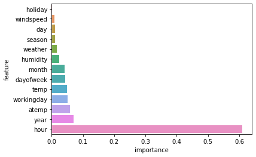

```python
sns.barplot(data=fi_df, x='importance', y='feature')
```

```python
import pandas as pd

df = pd.read_csv('test1.csv')
df
```

|  | datetime | season | holiday | workingday | weather | temp | atemp | humidity | windspeed | casual | registered | count |
| --- | --- | --- | --- | --- | --- | --- | --- | --- | --- | --- | --- | --- |
| 0 | 2011-01-01 00:00:00 | 1 | 0 | 0 | 1 | 9.84 | 14.395 | 81 | 0.0000 | 3 | 13 | 16 |
| 1 | 2011-01-01 01:00:00 | 1 | 0 | 0 | 1 | 9.02 | 13.635 | 80 | 0.0000 | 8 | 32 | 40 |
| 2 | 2011-01-01 02:00:00 | 1 | 0 | 0 | 1 | 9.02 | 13.635 | 80 | 0.0000 | 5 | 27 | 32 |
| 3 | 2011-01-01 03:00:00 | 1 | 0 | 0 | 1 | 9.84 | 14.395 | 75 | 0.0000 | 3 | 10 | 13 |
| 4 | 2011-01-01 04:00:00 | 1 | 0 | 0 | 1 | 9.84 | 14.395 | 75 | 0.0000 | 0 | 1 | 1 |
| ... | ... | ... | ... | ... | ... | ... | ... | ... | ... | ... | ... | ... |
| 10881 | 2012-12-19 19:00:00 | 4 | 0 | 1 | 1 | 15.58 | 19.695 | 50 | 26.0027 | 7 | 329 | 336 |
| 10882 | 2012-12-19 20:00:00 | 4 | 0 | 1 | 1 | 14.76 | 17.425 | 57 | 15.0013 | 10 | 231 | 241 |
| 10883 | 2012-12-19 21:00:00 | 4 | 0 | 1 | 1 | 13.94 | 15.910 | 61 | 15.0013 | 4 | 164 | 168 |
| 10884 | 2012-12-19 22:00:00 | 4 | 0 | 1 | 1 | 13.94 | 17.425 | 61 | 6.0032 | 12 | 117 | 129 |
| 10885 | 2012-12-19 23:00:00 | 4 | 0 | 1 | 1 | 13.12 | 16.665 | 66 | 8.9981 | 4 | 84 | 88 |

10886 rows × 12 columns

```python
set(df['holiday'])

# 중복된 경우의 수 제외
# Dictionary 형태로 선택
```

```
{0, 1}
```

```python
df['holiday'] == 1

# 해당 column에 저장된 값들에 대해 일괄 boolean 연산
```

```
0        False
1        False
2        False
3        False
4        False
         ...
10881    False
10882    False
10883    False
10884    False
10885    False
Name: holiday, Length: 10886, dtype: bool
```

```python
df.loc[df['holiday'] == 1]

# holiday column의 값이 1인 조건을 만족하는 Row를 선택
```

|  | datetime | season | holiday | workingday | weather | temp | atemp | humidity | windspeed | casual | registered | count |
| --- | --- | --- | --- | --- | --- | --- | --- | --- | --- | --- | --- | --- |
| 372 | 2011-01-17 00:00:00 | 1 | 1 | 0 | 2 | 8.20 | 9.850 | 47 | 15.0013 | 1 | 16 | 17 |
| 373 | 2011-01-17 01:00:00 | 1 | 1 | 0 | 2 | 8.20 | 9.850 | 44 | 12.9980 | 1 | 15 | 16 |
| 374 | 2011-01-17 02:00:00 | 1 | 1 | 0 | 2 | 7.38 | 8.335 | 43 | 16.9979 | 0 | 8 | 8 |
| 375 | 2011-01-17 03:00:00 | 1 | 1 | 0 | 2 | 7.38 | 9.090 | 43 | 12.9980 | 0 | 2 | 2 |
| 376 | 2011-01-17 04:00:00 | 1 | 1 | 0 | 2 | 7.38 | 9.850 | 43 | 8.9981 | 1 | 2 | 3 |
| ... | ... | ... | ... | ... | ... | ... | ... | ... | ... | ... | ... | ... |
| 10257 | 2012-11-12 19:00:00 | 4 | 1 | 0 | 1 | 22.14 | 25.760 | 73 | 19.0012 | 30 | 323 | 353 |
| 10258 | 2012-11-12 20:00:00 | 4 | 1 | 0 | 2 | 21.32 | 25.000 | 77 | 19.0012 | 31 | 273 | 304 |
| 10259 | 2012-11-12 21:00:00 | 4 | 1 | 0 | 3 | 22.14 | 25.760 | 73 | 15.0013 | 10 | 145 | 155 |
| 10260 | 2012-11-12 22:00:00 | 4 | 1 | 0 | 1 | 21.32 | 25.000 | 77 | 16.9979 | 12 | 100 | 112 |
| 10261 | 2012-11-12 23:00:00 | 4 | 1 | 0 | 2 | 22.14 | 25.760 | 77 | 15.0013 | 1 | 62 | 63 |

311 rows × 12 columns

```python
# cold 컬럼에 0 저장(없으니까 새로 생성)
df['cold'] = 0

# df에서 df['temp'] < 5 조건을 만족하는 Row에 대해 cold 컬럼에 1을 할당
df.loc[df['temp'] < 5, 'cold'] = 1
```

```python
df.head()
```

|  | datetime | season | holiday | workingday | weather | temp | atemp | humidity | windspeed | casual | registered | count | cold |
| --- | --- | --- | --- | --- | --- | --- | --- | --- | --- | --- | --- | --- | --- |
| 0 | 2011-01-01 00:00:00 | 1 | 0 | 0 | 1 | 9.84 | 14.395 | 81 | 0.0 | 3 | 13 | 16 | 0 |
| 1 | 2011-01-01 01:00:00 | 1 | 0 | 0 | 1 | 9.02 | 13.635 | 80 | 0.0 | 8 | 32 | 40 | 0 |
| 2 | 2011-01-01 02:00:00 | 1 | 0 | 0 | 1 | 9.02 | 13.635 | 80 | 0.0 | 5 | 27 | 32 | 0 |
| 3 | 2011-01-01 03:00:00 | 1 | 0 | 0 | 1 | 9.84 | 14.395 | 75 | 0.0 | 3 | 10 | 13 | 0 |
| 4 | 2011-01-01 04:00:00 | 1 | 0 | 0 | 1 | 9.84 | 14.395 | 75 | 0.0 | 0 | 1 | 1 | 0 |

```python
# Q1) holiday 컬럼이 1인 Row에 대해 temp 컬럼의 평균을 구하세요.
import numpy as np
np.mean(df.loc[df['holiday'] == 1]['temp'])
```

```
20.244244372990355
```

```python
# Q2) holiday 컬럼이 1인 Row와 그렇지 않은 Row에 대해
#     temp 컬럼의 평균의 차이를 제곱하세요.

h_1_mean = np.mean(df.loc[df['holiday'] == 1]['temp'])
h_0_mean = np.mean(df.loc[df['holiday'] != 1]['temp'])
(h_1_mean - h_0_mean) ** 2
```

```
0.0001898382203312306
```

```python
# Q3) holiday 컬럼이 0인 Row에 대하여 표준편차가 0.5 초과인 Column은 무엇인가?

# df.loc[df['holiday'] == 0] -> holiday 컬럼이 0인 Row를 선택
# .describe() -> 컬럼들의 표준편차를 일괄적으로 구함
# .T -> 표준편차(std)는 Column이 아니라 index 임
# .loc 해서 filtering을 하려면 컬럼에 있어야 해서 transpose 해서 컬럼 영역으로 옮김
desc = df.loc[df['holiday'] == 0].describe().T

# desc['std'] > 0.5 -> 표준편차가 0.5 초과인 Row를 Boolean 조건 True로
# desc.loc[desc['std'] > 0.5] -> 표준편차가 0.5 초과인 Row 선별
# .T -> 원본 데이터 셋 상 Column 이름들이 index에 있었으므로 다시 컬럼 영역으로
# .columns -> 컬럼 이름들을 확인
desc.loc[desc['std'] > 0.5].T.columns
```

```
Index(['season', 'weather', 'temp', 'atemp', 'humidity', 'windspeed', 'casual',
       'registered', 'count'],
      dtype='object')
```

## Function mapping

- Series나 DataFrame의 개별 원소를 특정 함수에 일대일 대응시키는 과정
- Pandas의 내장 함수로 처리하기 어려운 연산을 함수 매핑을 통해 Pandas 객체에 적용할 수 있음

```python
df['temp'] / 10
```

```
0        0.984
1        0.902
2        0.902
3        0.984
4        0.984
         ...
10881    1.558
10882    1.476
10883    1.394
10884    1.394
10885    1.312
Name: temp, Length: 10886, dtype: float64
```

```python
# .apply() -> 컬럼의 모든 값에 괄호 안에 있는 규칙을 적용함
df['temp'].apply(lambda x : x/10)

# lambda x : int(x)
```

```
0        0.984
1        0.902
2        0.902
3        0.984
4        0.984
         ...
10881    1.558
10882    1.476
10883    1.394
10884    1.394
10885    1.312
Name: temp, Length: 10886, dtype: float64
```

```python
sample = '2011-01-01 00:00:00'
year = sample[:4]
month = int(sample.split(' ')[0].split('-')[1])
day = int(sample.split(' ')[0].split('-')[2])
hour = int(sample.split(' ')[1].split(':')[0])
minute = int(sample.split(' ')[1].split(':')[1])
sec = int(sample.split(' ')[1].split(':')[2])
```

```python
print(year, month, day, hour, minute, sec)
```

```
2011 1 1 0 0 0
```

```python
df['year'] = df['datetime'].apply(lambda x : int(x[:4]))
df['month'] = df['datetime'].apply(lambda x : int(x.split(' ')[0].split('-')[1]))
df['day'] = df['datetime'].apply(lambda x : int(x.split(' ')[0].split('-')[2]))
df['hour'] = df['datetime'].apply(lambda x : int(x.split(' ')[1].split(':')[0]))

df.head()
```

|  | datetime | season | holiday | workingday | weather | temp | atemp | humidity | windspeed | casual | registered | count | cold | year | month | day | hour |
| --- | --- | --- | --- | --- | --- | --- | --- | --- | --- | --- | --- | --- | --- | --- | --- | --- | --- |
| 0 | 2011-01-01 00:00:00 | 1 | 0 | 0 | 1 | 9.84 | 14.395 | 81 | 0.0 | 3 | 13 | 16 | 0 | 2011 | 1 | 1 | 0 |
| 1 | 2011-01-01 01:00:00 | 1 | 0 | 0 | 1 | 9.02 | 13.635 | 80 | 0.0 | 8 | 32 | 40 | 0 | 2011 | 1 | 1 | 1 |
| 2 | 2011-01-01 02:00:00 | 1 | 0 | 0 | 1 | 9.02 | 13.635 | 80 | 0.0 | 5 | 27 | 32 | 0 | 2011 | 1 | 1 | 2 |
| 3 | 2011-01-01 03:00:00 | 1 | 0 | 0 | 1 | 9.84 | 14.395 | 75 | 0.0 | 3 | 10 | 13 | 0 | 2011 | 1 | 1 | 3 |
| 4 | 2011-01-01 04:00:00 | 1 | 0 | 0 | 1 | 9.84 | 14.395 | 75 | 0.0 | 0 | 1 | 1 | 0 | 2011 | 1 | 1 | 4 |

```python
# 2011년도 1월만 선택 -> year: 2011 & month: 1
# EZ한 방법

year = df.loc[df['year'] == 2011]
yearmonth = year.loc[year['month'] == 1]
yearmonth
```

|  | datetime | season | holiday | workingday | weather | temp | atemp | humidity | windspeed | casual | registered | count | cold | year | month | day | hour |
| --- | --- | --- | --- | --- | --- | --- | --- | --- | --- | --- | --- | --- | --- | --- | --- | --- | --- |
| 0 | 2011-01-01 00:00:00 | 1 | 0 | 0 | 1 | 9.84 | 14.395 | 81 | 0.0000 | 3 | 13 | 16 | 0 | 2011 | 1 | 1 | 0 |
| 1 | 2011-01-01 01:00:00 | 1 | 0 | 0 | 1 | 9.02 | 13.635 | 80 | 0.0000 | 8 | 32 | 40 | 0 | 2011 | 1 | 1 | 1 |
| 2 | 2011-01-01 02:00:00 | 1 | 0 | 0 | 1 | 9.02 | 13.635 | 80 | 0.0000 | 5 | 27 | 32 | 0 | 2011 | 1 | 1 | 2 |
| 3 | 2011-01-01 03:00:00 | 1 | 0 | 0 | 1 | 9.84 | 14.395 | 75 | 0.0000 | 3 | 10 | 13 | 0 | 2011 | 1 | 1 | 3 |
| 4 | 2011-01-01 04:00:00 | 1 | 0 | 0 | 1 | 9.84 | 14.395 | 75 | 0.0000 | 0 | 1 | 1 | 0 | 2011 | 1 | 1 | 4 |
| ... | ... | ... | ... | ... | ... | ... | ... | ... | ... | ... | ... | ... | ... | ... | ... | ... | ... |
| 426 | 2011-01-19 19:00:00 | 1 | 0 | 1 | 1 | 13.12 | 14.395 | 57 | 27.9993 | 4 | 108 | 112 | 0 | 2011 | 1 | 19 | 19 |
| 427 | 2011-01-19 20:00:00 | 1 | 0 | 1 | 1 | 13.12 | 15.150 | 49 | 19.9995 | 2 | 74 | 76 | 0 | 2011 | 1 | 19 | 20 |
| 428 | 2011-01-19 21:00:00 | 1 | 0 | 1 | 1 | 13.12 | 14.395 | 49 | 27.9993 | 4 | 55 | 59 | 0 | 2011 | 1 | 19 | 21 |
| 429 | 2011-01-19 22:00:00 | 1 | 0 | 1 | 1 | 12.30 | 15.150 | 52 | 11.0014 | 6 | 53 | 59 | 0 | 2011 | 1 | 19 | 22 |
| 430 | 2011-01-19 23:00:00 | 1 | 0 | 1 | 1 | 12.30 | 13.635 | 52 | 31.0009 | 1 | 27 | 28 | 0 | 2011 | 1 | 19 | 23 |

431 rows × 17 columns

```python
df.loc[(df['year'] == 2011) & (df['month'] == 1)]
```

|  | datetime | season | holiday | workingday | weather | temp | atemp | humidity | windspeed | casual | registered | count | cold | year | month | day | hour |
| --- | --- | --- | --- | --- | --- | --- | --- | --- | --- | --- | --- | --- | --- | --- | --- | --- | --- |
| 0 | 2011-01-01 00:00:00 | 1 | 0 | 0 | 1 | 9.84 | 14.395 | 81 | 0.0000 | 3 | 13 | 16 | 0 | 2011 | 1 | 1 | 0 |
| 1 | 2011-01-01 01:00:00 | 1 | 0 | 0 | 1 | 9.02 | 13.635 | 80 | 0.0000 | 8 | 32 | 40 | 0 | 2011 | 1 | 1 | 1 |
| 2 | 2011-01-01 02:00:00 | 1 | 0 | 0 | 1 | 9.02 | 13.635 | 80 | 0.0000 | 5 | 27 | 32 | 0 | 2011 | 1 | 1 | 2 |
| 3 | 2011-01-01 03:00:00 | 1 | 0 | 0 | 1 | 9.84 | 14.395 | 75 | 0.0000 | 3 | 10 | 13 | 0 | 2011 | 1 | 1 | 3 |
| 4 | 2011-01-01 04:00:00 | 1 | 0 | 0 | 1 | 9.84 | 14.395 | 75 | 0.0000 | 0 | 1 | 1 | 0 | 2011 | 1 | 1 | 4 |
| ... | ... | ... | ... | ... | ... | ... | ... | ... | ... | ... | ... | ... | ... | ... | ... | ... | ... |
| 426 | 2011-01-19 19:00:00 | 1 | 0 | 1 | 1 | 13.12 | 14.395 | 57 | 27.9993 | 4 | 108 | 112 | 0 | 2011 | 1 | 19 | 19 |
| 427 | 2011-01-19 20:00:00 | 1 | 0 | 1 | 1 | 13.12 | 15.150 | 49 | 19.9995 | 2 | 74 | 76 | 0 | 2011 | 1 | 19 | 20 |
| 428 | 2011-01-19 21:00:00 | 1 | 0 | 1 | 1 | 13.12 | 14.395 | 49 | 27.9993 | 4 | 55 | 59 | 0 | 2011 | 1 | 19 | 21 |
| 429 | 2011-01-19 22:00:00 | 1 | 0 | 1 | 1 | 12.30 | 15.150 | 52 | 11.0014 | 6 | 53 | 59 | 0 | 2011 | 1 | 19 | 22 |
| 430 | 2011-01-19 23:00:00 | 1 | 0 | 1 | 1 | 12.30 | 13.635 | 52 | 31.0009 | 1 | 27 | 28 | 0 | 2011 | 1 | 19 | 23 |

431 rows × 17 columns

## 그룹 연산

- 특정 기준으로 그룹을 분할하여 처리
- 그룹 연산은 데이터를 집계, 변환, 필터링하는데 효율적

```python
# 그룹 분할: df.groupby(기준이 되는 컬럼)
# 그룹에 적용: 그룹.agg(매핑 함수)
# 특정 컬럼 A를 정해서 A의 경우의 수로 그룹 짓고,
# 각 그룹별로 한 그룹당 특정 컬럼 B를 정해 B 안의 값들을
# 일괄적으로 합쳐서 계산

# year 컬럼의 경우의 수 기준으로 Row들을 그룹 지음
year = df.groupby('year')

# .agg() -> 그룹 별로 합산 연산
# {'count':np.mean} -> count 컬럼에 대해 np.mean 연산을 일괄 수행
year_count = year.agg({'count':np.mean})
year_count.reset_index()
```

|  | year | count |
| --- | --- | --- |
| 0 | 2011 | 144.223349 |
| 1 | 2012 | 238.560944 |

```python
# 한 줄로 처리
df.groupby('year').agg({'count':np.mean}).reset_index()
```

|  | year | count |
| --- | --- | --- |
| 0 | 2011 | 144.223349 |
| 1 | 2012 | 238.560944 |

```python
# multi-index Aggregation

interested = ['year', 'season']
ys_count = df.groupby(interested).agg({'count':np.mean}).reset_index()
ys_count
```

|  | year | season | count |
| --- | --- | --- | --- |
| 0 | 2011 | 1 | 71.905518 |
| 1 | 2011 | 2 | 160.940746 |
| 2 | 2011 | 3 | 186.994872 |
| 3 | 2011 | 4 | 154.787125 |
| 4 | 2012 | 1 | 159.476889 |
| 5 | 2012 | 2 | 269.601757 |
| 6 | 2012 | 3 | 281.735380 |
| 7 | 2012 | 4 | 243.189466 |

```python
# 요일 정보 추출

sample = '2011-01-01 00:00:00'
parsed = pd.to_datetime(sample)
parsed
```

```
Timestamp('2011-01-01 00:00:00')
```

```python
parsed.dayofweek

# dayofweek: 요일
# 0(mon) ~ 6(sun)
```

```
5
```

```python
df.head()
```

|  | datetime | season | holiday | workingday | weather | temp | atemp | humidity | windspeed | casual | registered | count | cold | year | month | day | hour |
| --- | --- | --- | --- | --- | --- | --- | --- | --- | --- | --- | --- | --- | --- | --- | --- | --- | --- |
| 0 | 2011-01-01 00:00:00 | 1 | 0 | 0 | 1 | 9.84 | 14.395 | 81 | 0.0 | 3 | 13 | 16 | 0 | 2011 | 1 | 1 | 0 |
| 1 | 2011-01-01 01:00:00 | 1 | 0 | 0 | 1 | 9.02 | 13.635 | 80 | 0.0 | 8 | 32 | 40 | 0 | 2011 | 1 | 1 | 1 |
| 2 | 2011-01-01 02:00:00 | 1 | 0 | 0 | 1 | 9.02 | 13.635 | 80 | 0.0 | 5 | 27 | 32 | 0 | 2011 | 1 | 1 | 2 |
| 3 | 2011-01-01 03:00:00 | 1 | 0 | 0 | 1 | 9.84 | 14.395 | 75 | 0.0 | 3 | 10 | 13 | 0 | 2011 | 1 | 1 | 3 |
| 4 | 2011-01-01 04:00:00 | 1 | 0 | 0 | 1 | 9.84 | 14.395 | 75 | 0.0 | 0 | 1 | 1 | 0 | 2011 | 1 | 1 | 4 |

```python
lambda x : pd.to_datetime(sample).dayofweek
```

```
<function __main__.<lambda>(x)>
```

```python
df['dayofweek'] = df['datetime'].apply(lambda x : pd.to_datetime(x).dayofweek)
df.head()
```

|  | datetime | season | holiday | workingday | weather | temp | atemp | humidity | windspeed | casual | registered | count | cold | year | month | day | hour | dayofweek |
| --- | --- | --- | --- | --- | --- | --- | --- | --- | --- | --- | --- | --- | --- | --- | --- | --- | --- | --- |
| 0 | 2011-01-01 00:00:00 | 1 | 0 | 0 | 1 | 9.84 | 14.395 | 81 | 0.0 | 3 | 13 | 16 | 0 | 2011 | 1 | 1 | 0 | 5 |
| 1 | 2011-01-01 01:00:00 | 1 | 0 | 0 | 1 | 9.02 | 13.635 | 80 | 0.0 | 8 | 32 | 40 | 0 | 2011 | 1 | 1 | 1 | 5 |
| 2 | 2011-01-01 02:00:00 | 1 | 0 | 0 | 1 | 9.02 | 13.635 | 80 | 0.0 | 5 | 27 | 32 | 0 | 2011 | 1 | 1 | 2 | 5 |
| 3 | 2011-01-01 03:00:00 | 1 | 0 | 0 | 1 | 9.84 | 14.395 | 75 | 0.0 | 3 | 10 | 13 | 0 | 2011 | 1 | 1 | 3 | 5 |
| 4 | 2011-01-01 04:00:00 | 1 | 0 | 0 | 1 | 9.84 | 14.395 | 75 | 0.0 | 0 | 1 | 1 | 0 | 2011 | 1 | 1 | 4 | 5 |

```python
df.columns
```

```
Index(['datetime', 'season', 'holiday', 'workingday', 'weather', 'temp',
       'atemp', 'humidity', 'windspeed', 'casual', 'registered', 'count',
       'cold', 'year', 'month', 'day', 'hour', 'dayofweek'],
      dtype='object')
```

```python
interested = ['season', 'holiday', 'workingday', 'weather', 'temp',
       'atemp', 'humidity', 'windspeed', 'casual', 'registered', 'count',
       'cold', 'year', 'month', 'day', 'hour', 'dayofweek']

df[interested].to_csv('test1_modify.csv', index=False)
```

```python
df = pd.read_csv('test1_modify.csv')
df
```

|  | season | holiday | workingday | weather | temp | atemp | humidity | windspeed | casual | registered | count | cold | year | month | day | hour | dayofweek |
| --- | --- | --- | --- | --- | --- | --- | --- | --- | --- | --- | --- | --- | --- | --- | --- | --- | --- |
| 0 | 1 | 0 | 0 | 1 | 9.84 | 14.395 | 81 | 0.0000 | 3 | 13 | 16 | 0 | 2011 | 1 | 1 | 0 | 5 |
| 1 | 1 | 0 | 0 | 1 | 9.02 | 13.635 | 80 | 0.0000 | 8 | 32 | 40 | 0 | 2011 | 1 | 1 | 1 | 5 |
| 2 | 1 | 0 | 0 | 1 | 9.02 | 13.635 | 80 | 0.0000 | 5 | 27 | 32 | 0 | 2011 | 1 | 1 | 2 | 5 |
| 3 | 1 | 0 | 0 | 1 | 9.84 | 14.395 | 75 | 0.0000 | 3 | 10 | 13 | 0 | 2011 | 1 | 1 | 3 | 5 |
| 4 | 1 | 0 | 0 | 1 | 9.84 | 14.395 | 75 | 0.0000 | 0 | 1 | 1 | 0 | 2011 | 1 | 1 | 4 | 5 |
| ... | ... | ... | ... | ... | ... | ... | ... | ... | ... | ... | ... | ... | ... | ... | ... | ... | ... |
| 10881 | 4 | 0 | 1 | 1 | 15.58 | 19.695 | 50 | 26.0027 | 7 | 329 | 336 | 0 | 2012 | 12 | 19 | 19 | 2 |
| 10882 | 4 | 0 | 1 | 1 | 14.76 | 17.425 | 57 | 15.0013 | 10 | 231 | 241 | 0 | 2012 | 12 | 19 | 20 | 2 |
| 10883 | 4 | 0 | 1 | 1 | 13.94 | 15.910 | 61 | 15.0013 | 4 | 164 | 168 | 0 | 2012 | 12 | 19 | 21 | 2 |
| 10884 | 4 | 0 | 1 | 1 | 13.94 | 17.425 | 61 | 6.0032 | 12 | 117 | 129 | 0 | 2012 | 12 | 19 | 22 | 2 |
| 10885 | 4 | 0 | 1 | 1 | 13.12 | 16.665 | 66 | 8.9981 | 4 | 84 | 88 | 0 | 2012 | 12 | 19 | 23 | 2 |

10886 rows × 17 columns